# Factor Analysis

pg606@scarletmail.rutgers.edu

2024-03-19

```r
library(psych)
data <- read.csv("/Users/Prateekg/Downloads/data1.csv", row.names=1)
attach(data)
data[1]
```

```
##                                    salary
## AI Architect                       185900
## AI Developer                       129300
## AI Engineer                         94500
## AI Programmer                      122000
## BI Analyst                         182200
## BI Data Analyst                     95000
## BI Developer                       142201
## BI Developer Manager               142200
## Big Data Engineer                  152000
## Business Intelligence Analyst      273400
## Business Intelligence Engineer     204501
## Computer Vision Software Engineer  204500
## Data Analyst                       234000
## Data Architect                     266500
## Data Engineer                      300000
## Data Infrastructure Engineer       186000
## Data Integration Engineer           88000
## Data Lead                           79600
## Data Management Analyst            100000
## Data Management Specialist         139700
## Data Manager                       168000
## Data Modeler                       176000
## Data Operations Analyst            185000
## Data Operations Engineer           210000
## Data Operations Manager            210010
## Data Operations Specialist         247300
## Data Product Manager                30000
## Data Product Owner                  75000
## Data Quality Analyst               120000
## Data Quality Engineer              140000
## Data Science Consultant           1862010
## Data Science Director              212000
## Data Science Engineer              223450
## Data Science Lead                   35000
## Data Science Manager               106500
## Data Science Practitioner          110000
## Data Science Tech Lead             127300
## Data Scientist                     136000
## Data Scientist Lead                155000
## Data Specialist                    167500
## Data Strategist                    222200
## Data Strategy Manager              224400
## Data Visualization Analyst         224420
## Data Visualization Engineer        247600
## Data Visualization Specialist      138700
## Decision Scientist                 224401
## Deep Learning Engineer             224402
## Deep Learning Researcher           186200
## Director of Data Science           223400
```

```r
fit.pc <- principal(data[-1], nfactors=4, rotate="varimax")
fit.pc
```

```
## Principal Components Analysis
## Call: principal(r = data[-1], nfactors = 4, rotate = "varimax")
## Standardized loadings (pattern matrix) based upon correlation matrix
##                           RC1  RC2   RC4   RC3   h2      u2 com
## salary_in_usd           -0.14 0.01 -0.04  0.99 1.00 8.9e-07 1.0
## years_experience        -0.73 0.46 -0.20  0.10 0.79 2.1e-01 1.9
## Salary_Level_Numeric    -0.03 0.96  0.08  0.00 0.93 6.9e-02 1.0
## Salary_Experience_Ratio  0.92 0.11  0.08 -0.12 0.89 1.1e-01 1.1
## Location_Diversity       0.15 0.06  0.98 -0.04 0.99 7.1e-03 1.1
##
##                        RC1  RC2  RC4  RC3
## SS loadings           1.43 1.15 1.02 1.01
## Proportion Var        0.29 0.23 0.20 0.20
## Cumulative Var        0.29 0.52 0.72 0.92
## Proportion Explained  0.31 0.25 0.22 0.22
## Cumulative Proportion 0.31 0.56 0.78 1.00
##
## Mean item complexity =  1.2
## Test of the hypothesis that 4 components are sufficient.
##
## The root mean square of the residuals (RMSR) is  0.07
##  with the empirical chi square  4.67  with prob <  NA
##
## Fit based upon off diagonal values = 0.92
```

```r
round(fit.pc$values, 3)
```

```
## [1] 1.847 1.171 0.904 0.684 0.393
```

```r
fit.pc$loadings
```

```
##
## Loadings:
##                         RC1    RC2    RC4    RC3
## salary_in_usd           -0.138                0.990
## years_experience        -0.729  0.464 -0.197
## Salary_Level_Numeric            0.961
## Salary_Experience_Ratio  0.924  0.113        -0.123
## Location_Diversity       0.151         0.983
##
##                  RC1   RC2   RC4   RC3
## SS loadings    1.428 1.154 1.019 1.005
## Proportion Var 0.286 0.231 0.204 0.201
## Cumulative Var 0.286 0.516 0.720 0.921
```

```r
for (i in c(1,3,2,4)) { print(fit.pc$loadings[[1,i]])}
```

```
## [1] -0.1383288
## [1] -0.03609081
## [1] 0.007569127
## [1] 0.9896991
```

```r
fit.pc$communality
```

```
##           salary_in_usd        years_experience    Salary_Level_Numeric
##               0.9999991               0.7948565               0.9308215
## Salary_Experience_Ratio      Location_Diversity
##               0.8880785               0.9928592
```

```r
fit.pc$scores
```

```
##                                           RC1          RC2           RC4
## AI Architect                      -0.83395320 -0.321382708  0.3209287754
## AI Developer                      -0.63534508  0.376420814  0.2256729419
## AI Engineer                        1.25185878 -1.296211814  0.2211587167
## AI Programmer                      1.76333655  1.584400829  0.0892547618
## BI Analyst                        -0.67646433  1.124120487 -0.0333683112
## BI Data Analyst                    0.84983329 -1.936501716  3.2615066995
## BI Developer                      -0.48649986  0.117921565 -0.4622771081
## BI Developer Manager               1.86150571  0.906704152  0.1977776547
## Big Data Engineer                  0.41150780 -0.540112850 -0.3283318063
## Business Intelligence Analyst     -0.47223932 -0.073362523  0.0461759121
## Business Intelligence Engineer     2.13007226 -1.002919812 -0.8357993411
## Computer Vision Software Engineer  3.60562588  0.150035368  0.0734820757
## Data Analyst                       0.49348457 -0.617407519 -0.6905304242
## Data Architect                    -0.06679176 -1.233719081 -0.1110558220
## Data Engineer                     -0.21613069 -0.627335465 -0.5895004376
## Data Infrastructure Engineer      -0.48901872 -0.166733974 -1.0781389755
## Data Integration Engineer         -0.75672208 -2.114160846  2.9499734839
## Data Lead                         -0.59569108  0.751444488  0.2138995485
## Data Management Analyst            2.72222616  1.687001214  0.2218344334
## Data Management Specialist        -0.51396719 -0.417572674  0.3445097831
## Data Manager                      -0.10386080 -1.508526568 -0.9788811359
## Data Modeler                       0.41135390  2.480977894  0.2181531231
## Data Operations Analyst            0.20537419 -1.135669559  0.2915746033
## Data Operations Engineer          -0.65278420  0.629115984 -1.4516671830
## Data Operations Manager           -0.50615691 -0.016349950 -1.2565493565
## Data Operations Specialist        -1.15218239 -0.862805246  0.5545743999
## Data Product Manager              -0.45994467  0.051763830 -1.4189928503
## Data Product Owner                 0.00251920  0.453336993 -0.8955976539
## Data Quality Analyst              -0.83894448  0.431809917 -0.5392912305
## Data Quality Engineer              0.26139491  0.393778119 -0.7828875907
## Data Science Consultant           -0.12606330  0.362367594  1.3203858255
## Data Science Director             -0.85828188 -0.209415079 -1.5038817138
## Data Science Engineer             -0.11951938  0.195009847  1.2982993337
## Data Science Lead                  0.23505622 -0.897827339 -1.0356228504
## Data Science Manager              -0.47174415 -0.389089778  0.1581178174
## Data Science Practitioner         -1.31940585  0.688675508 -0.2847854659
## Data Science Tech Lead            -0.63937544  1.305690642  0.9211534301
## Data Scientist                     0.49143495 -0.525809904 -0.2921299008
## Data Scientist Lead                0.36476766 -0.188973699 -0.5663174670
```

[output cut: 45 more lines]

```
## Data Science Manager              -1.09754130
## Data Science Practitioner         -1.18162840
## Data Science Tech Lead            -0.76012044
## Data Scientist                    -0.48607603
## Data Scientist Lead               -0.20010410
## Data Specialist                    0.05672458
## Data Strategist                    0.71172706
## Data Strategy Manager              0.87207363
## Data Visualization Analyst         0.88105857
## Data Visualization Engineer        1.26774967
## Data Visualization Specialist     -0.58790012
## Decision Scientist                 0.87914252
## Deep Learning Engineer             0.87088153
## Deep Learning Researcher           0.22077341
## Director of Data Science           0.87025679
```

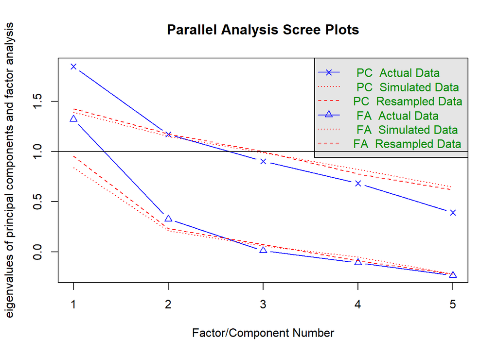

```
## Parallel analysis suggests that the number of factors =  1  and the number of components =  1
```

```r
fa.parallel(data[-1])
```

# Question1: Decide how many Factors are ideal for your dataset?

# In this case, the output suggests that the parallel analysis suggests that the number of factors is 1, and the number of components is 1. However, based on the initial factor analysis performed, it seems like four factors (RC1, RC2, RC3, RC4) have been extracted.

# Question 2: Explain the output for your factor model?

#• Standardized loadings (pattern matrix) based upon the correlation matrix: This table shows the relationships between the original variables and the extracted factors. Each cell represents the correlation between a variable and a factor.

#• SS loadings: This indicates the sum of squared loadings for each factor, providing information about how much variance in the original variables is explained by each factor.

#• Proportion Var: This represents the proportion of variance explained by each factor.

#• Cumulative Var: It shows the cumulative proportion of variance explained by the factors.

#• Proportion Explained: This shows the proportion of total variance explained by each factor.

#• Cumulative Proportion: It indicates the cumulative proportion of total variance explained by the factors.

#• Mean item complexity: This indicates the average number of parameters required to describe an item.

#• Test of the hypothesis that 4 components are sufficient: This section provides statistical tests to determine the adequacy of the chosen number of factors.

#• Root mean square of the residuals (RMSR) and empirical chi-square: These are measures of how well the model fits the data.

# Question 3: Show the columns that go into each factor?

#RC1: Salary experience ratio and years of experience.

#RC2: Salary level.

#Question 4: Perform some visualizations using the factors?

#Below are the Visualizations-

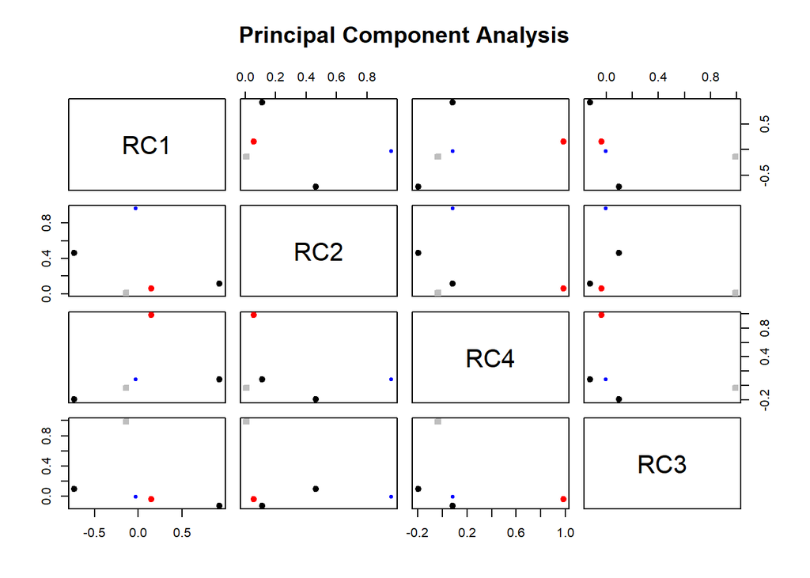

```r
fa.plot(fit.pc)
```

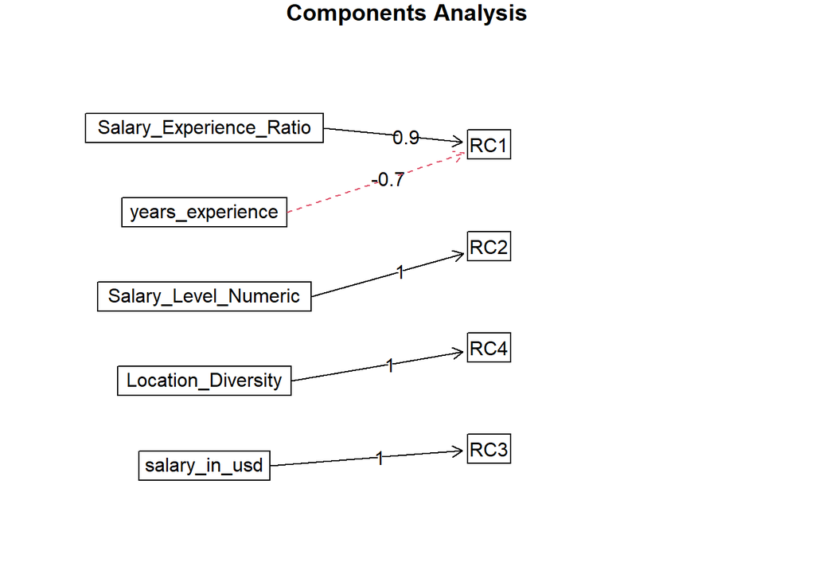

```r
fa.diagram(fit.pc)
```

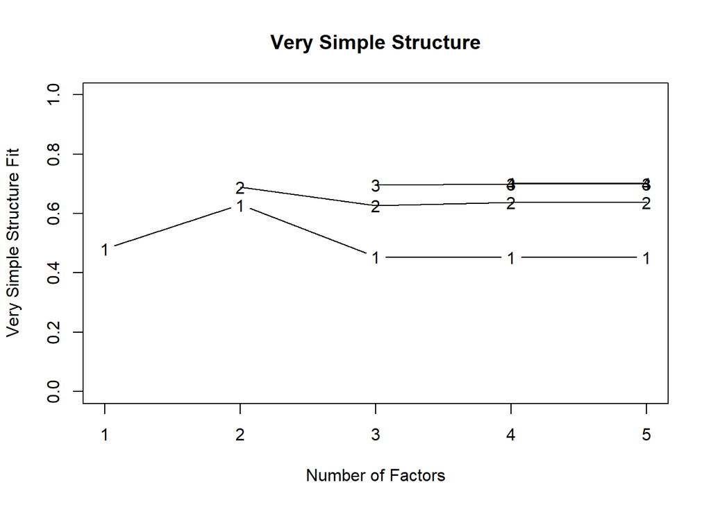

```
##
## Very Simple Structure
## Call: vss(x = data[-1])
## VSS complexity 1 achieves a maximimum of 0.63  with  2  factors
## VSS complexity 2 achieves a maximimum of 0.69  with  2  factors
##
## The Velicer MAP achieves a minimum of 0.09  with  1  factors
## BIC achieves a minimum of  -12.28  with  1  factors
## Sample Size adjusted BIC achieves a minimum of  -0.57  with  2  factors
##
## Statistics by number of factors
##   vss1 vss2   map dof   chisq prob sqresid  fit RMSEA   BIC SABIC complex
## 1 0.48 0.00 0.087   5 7.2e+00 0.21     3.2 0.48 0.092 -12.3  3.41     1.0
## 2 0.63 0.69 0.185   1 1.8e-01 0.67     1.9 0.69 0.000  -3.7 -0.57     1.1
## 3 0.45 0.63 0.449  -2 9.0e-11   NA     1.9 0.70    NA    NA    NA     1.6
## 4 0.45 0.64 1.000  -4 0.0e+00   NA     1.9 0.70    NA    NA    NA     1.7
## 5 0.45 0.64    NA  -5 0.0e+00   NA     1.9 0.70    NA    NA    NA     1.7
##    eChisq    SRMR eCRMS  eBIC
## 1 8.5e+00 9.3e-02 0.132 -11.0
## 2 1.8e-01 1.3e-02 0.043  -3.7
## 3 5.9e-11 2.5e-07    NA    NA
## 4 3.4e-15 1.9e-09    NA    NA
## 5 3.4e-15 1.9e-09    NA    NA
```

```r
vss(data[-1])
```